# IE 440 - Homework 1

Yusuf Ulucoban - Mustafa Comert

07 11 2021

# Graph of the Function

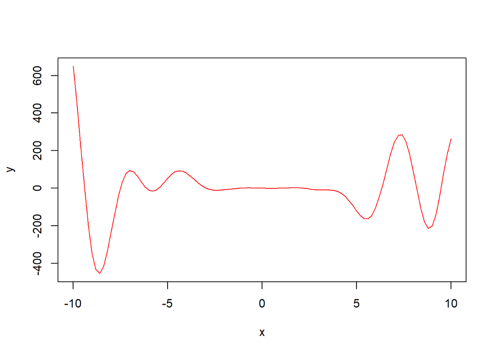

```r
draw <- curve(((x^3)*cos(x)*sin(x)) + (3 * (x^2) * sin(x)) - (3 * x), from=-10, to=10, , xlab="x", ylab="y", col="red")
```

```r
fx<-function(x)(((x^3)*cos(x)*sin(x)) + (3 * (x^2) * sin(x)) - (3 * x))
```

# 1-) Bisection Method

The bisection technique is a root-finding approach in mathematics that may be used to any continuous function for which two values with opposing sides of the unimodel graph are known. The interval searching technique, also known as the binary search method or the dichotomy approach, is a method for interval searches.

### Inputs, Outputs and Function Code

Inputs : epsilon(e), lower bound(a), upper bound(b), function(fx)  
Outputs : x’, f(x’)

```r
bisection_method <- function(e,a,b,fx){
  i <- 1
  k <- a
  kp <- b
  while(b-a>=e){
    temp <- (a + b) / 2
    if(fx(temp+e) <= fx(temp)){
      cat(i,a,b,temp,fx(temp),(abs(temp-kp)/abs(kp-k)),(-log(abs(temp-kp))+log(abs(kp-k))), "\n")
      a <- temp
      i <- i+1
    }
    else{
      cat(i,a,b,temp,fx(temp),(abs(temp-kp)/abs(kp-k)),(-log(abs(temp-kp))+log(abs(kp-k))), "\n")
      b <- temp
      i <- i+1
    }
    k=kp
    kp=temp
  }
}
```

### Parameters 1

Function is called with values e=0.01, a=4, b=6.

```r
bisection_method(0.01,4,6,fx)
```

```
## 1 4 6 5 -120.9206 0.5 0.6931472
## 2 5 6 5.5 -163.7145 0.5 0.6931472
## 3 5.5 6 5.75 -150.8808 0.5 0.6931472
## 4 5.5 5.75 5.625 -161.0615 0.5 0.6931472
## 5 5.5 5.625 5.5625 -163.2782 0.5 0.6931472
## 6 5.5 5.5625 5.53125 -163.7114 0.5 0.6931472
## 7 5.5 5.53125 5.515625 -163.7657 0.5 0.6931472
## 8 5.5 5.515625 5.507812 -163.7531 0.5 0.6931472
```

The minimum point is (5.507812,-163.7531).

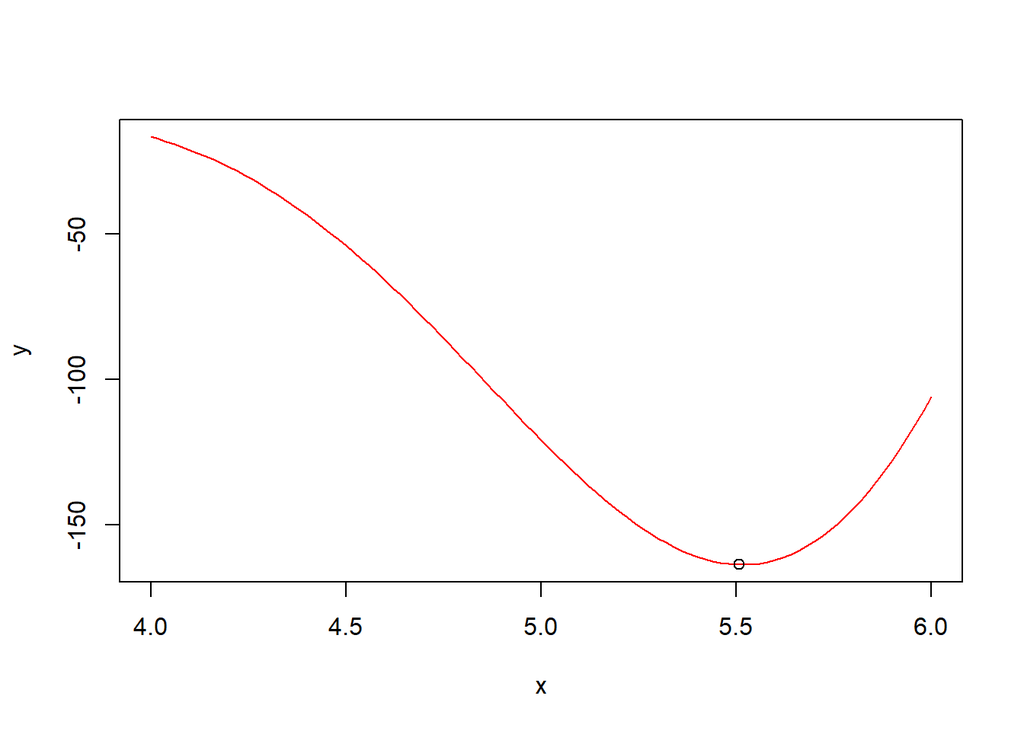

### Parameters 2

Function is called with values e=0.001, a=-10, b=-7.

```r
bisection_method(0.001,-10,-7,fx)
```

```
## 1 -10 -7 -8.5 -442.7812 0.5 0.6931472
## 2 -10 -8.5 -9.25 -152.4139 0.5 0.6931472
## 3 -9.25 -8.5 -8.875 -408.2662 0.5 0.6931472
## 4 -8.875 -8.5 -8.6875 -452.47 0.5 0.6931472
## 5 -8.6875 -8.5 -8.59375 -453.8813 0.5 0.6931472
## 6 -8.6875 -8.59375 -8.640625 -454.8147 0.5 0.6931472
## 7 -8.640625 -8.59375 -8.617188 -454.7492 0.5 0.6931472
## 8 -8.640625 -8.617188 -8.628906 -454.8834 0.5 0.6931472
## 9 -8.640625 -8.628906 -8.634766 -454.8745 0.5 0.6931472
## 10 -8.634766 -8.628906 -8.631836 -454.8853 0.5 0.6931472
## 11 -8.631836 -8.628906 -8.630371 -454.8859 0.5 0.6931472
## 12 -8.631836 -8.630371 -8.631104 -454.886 0.5 0.6931472
```

The minimum point is (-8.631104,-454.886).

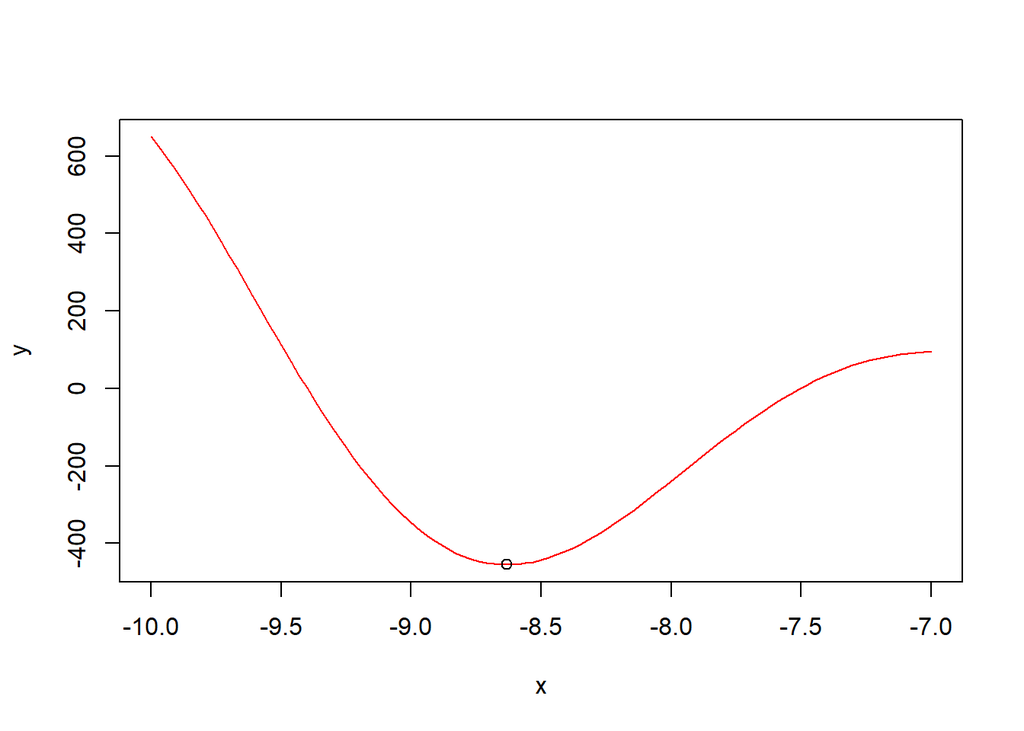

### Parameters 3

Function is called with values e=0.0001, a=-6.5, b=-5.

```r
bisection_method(0.0001,-6.5,-5,fx)
```

```
## 1 -6.5 -5 -5.75 -15.5509 0.5 0.6931472
## 2 -6.5 -5.75 -6.125 0.3591066 0.5 0.6931472
## 3 -6.125 -5.75 -5.9375 -13.08161 0.5 0.6931472
## 4 -5.9375 -5.75 -5.84375 -15.71707 0.5 0.6931472
## 5 -5.84375 -5.75 -5.796875 -15.98005 0.5 0.6931472
## 6 -5.84375 -5.796875 -5.820312 -15.93593 0.5 0.6931472
## 7 -5.820312 -5.796875 -5.808594 -15.97975 0.5 0.6931472
## 8 -5.808594 -5.796875 -5.802734 -15.98533 0.5 0.6931472
## 9 -5.802734 -5.796875 -5.799805 -15.98404 0.5 0.6931472
## 10 -5.802734 -5.799805 -5.80127 -15.98502 0.5 0.6931472
## 11 -5.802734 -5.80127 -5.802002 -15.98526 0.5 0.6931472
## 12 -5.802734 -5.802002 -5.802368 -15.98531 0.5 0.6931472
## 13 -5.802734 -5.802368 -5.802551 -15.98533 0.5 0.6931472
## 14 -5.802734 -5.802551 -5.802643 -15.98533 0.5 0.6931472
```

The minimum point is (-5.802643,-15.98533).

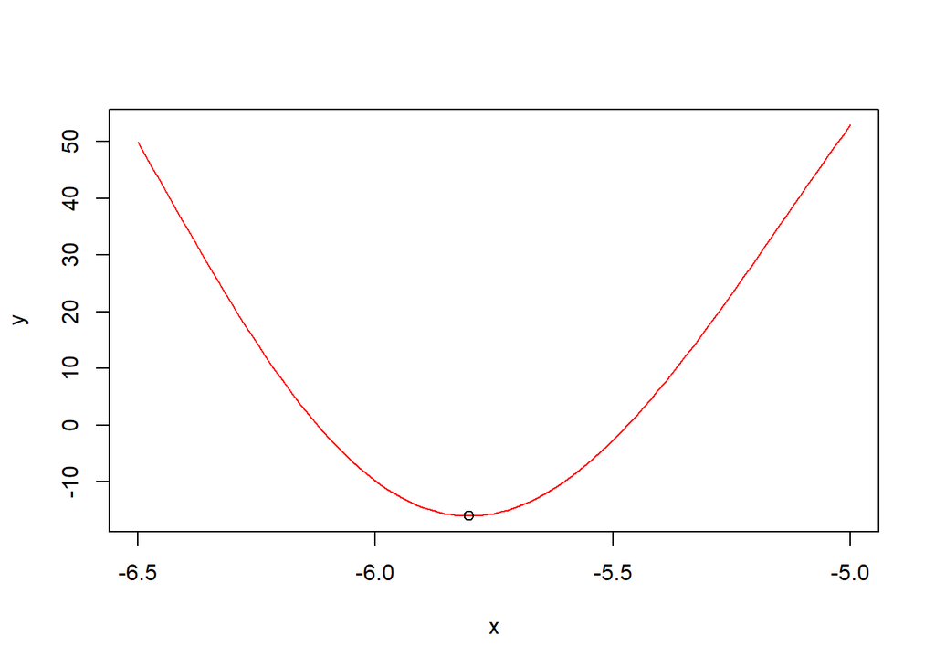

# 2-) Goldensection Method

The golden-section search is a good approach to find the minimum by gradually reducing the gap. The key is to notice that the minimum exists inside the interval formed by the two points next to the point with the least value so far analyzed, regardless of how many points have been evaluated.

### Inputs, Outputs and Function Code

Inputs : epsilon(e), lower bound(a), upper bound(b), function(fx)  
Outputs : x’, f(x’)

```r
goldensection_method <- function(e,a,b,fx){
  golden = 2/(sqrt(5) + 1)
  k <- a
  kp <- b
  i <- 1
  x <- b - golden*(b-a)
  y <- a + golden*(b-a)
  y0 <- fx(x)
  y1 <- fx(y)
  while(b-a > e){
    if(y0 >= y1){
      a <- x
      x <- y
      y <- a + golden * (b-a)
      y0 <- y1
      y1 <- fx(y)
      cat(i,a,b,x,y,fx(x),fx(y),(abs(y-kp)/abs(kp-k)),(-log(abs(y-kp))+log(abs(kp-k))),"\n")
      i <- i+1
      k=kp
      kp=y
    }
    else{
      b <- y
      y <- x
      x <- b - golden * (b-a)
      y1 <- y0
      y0 <- fx(x)
      cat(i,a,b,x,y,fx(x),fx(y),(abs(x-kp)/abs(kp-k)),(-log(abs(x-kp))+log(abs(kp-k))),"\n")
      i <- i+1
      k=kp
      kp=x
    }
  }
}
```

### Parameters 1

Function is called with values e=0.01, a=4, b=6.

```r
goldensection_method(0.01,4,6,fx)
```

```
## 1 4.763932 6 5.236068 5.527864 -149.1014 -163.7322 0.236068 1.443635
## 2 5.236068 6 5.527864 5.708204 -163.7322 -155.1662 0.381966 0.9624237
## 3 5.236068 5.708204 5.416408 5.527864 -161.7383 -163.7322 1.618034 -0.4812118
## 4 5.416408 5.708204 5.527864 5.596748 -163.7322 -162.2914 0.618034 0.4812118
## 5 5.416408 5.596748 5.485292 5.527864 -163.5717 -163.7322 0.618034 0.4812118
## 6 5.485292 5.596748 5.527864 5.554175 -163.7322 -163.4365 0.618034 0.4812118
## 7 5.485292 5.554175 5.511603 5.527864 -163.7625 -163.7322 0.618034 0.4812118
## 8 5.485292 5.527864 5.501553 5.511603 -163.7242 -163.7625 0.236068 1.443635
## 9 5.501553 5.527864 5.511603 5.517814 -163.7625 -163.7645 1.618034 -0.4812118
## 10 5.511603 5.527864 5.517814 5.521653 -163.7645 -163.7573 0.236068 1.443635
## 11 5.511603 5.521653 5.515442 5.517814 -163.7657 -163.7645 1.618034 -0.4812118
## 12 5.511603 5.517814 5.513975 5.515442 -163.7652 -163.7657 0.236068 1.443635
```

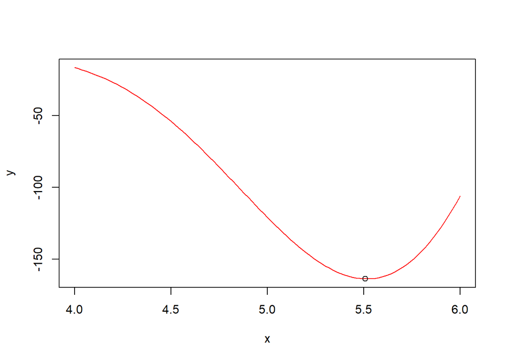

### Parameters 2

Function is called with values e=0.001, a=-10, b=-7.

```r
goldensection_method(0.001,-10,-7,fx)
```

```
## 1 -10 -8.145898 -9.291796 -8.854102 -111.896 -416.0303 0.763932 0.2692765
## 2 -9.291796 -8.145898 -8.854102 -8.583592 -416.0303 -453.2606 0.309017 1.174359
## 3 -8.854102 -8.145898 -8.583592 -8.416408 -453.2606 -423.4644 0.236068 1.443635
## 4 -8.854102 -8.416408 -8.686918 -8.583592 -452.5197 -453.2606 1.618034 -0.4812118
## 5 -8.686918 -8.416408 -8.583592 -8.519733 -453.2606 -446.0923 0.618034 0.4812118
## 6 -8.686918 -8.519733 -8.623059 -8.583592 -454.8416 -453.2606 0.618034 0.4812118
## 7 -8.686918 -8.583592 -8.647451 -8.623059 -454.6803 -454.8416 0.236068 1.443635
## 8 -8.647451 -8.583592 -8.623059 -8.607984 -454.8416 -454.5031 1.618034 -0.4812118
## 9 -8.647451 -8.607984 -8.632376 -8.623059 -454.8843 -454.8416 0.618034 0.4812118
## 10 -8.647451 -8.623059 -8.638134 -8.632376 -454.8464 -454.8843 0.236068 1.443635
## 11 -8.638134 -8.623059 -8.632376 -8.628817 -454.8843 -454.8831 1.618034 -0.4812118
## 12 -8.638134 -8.628817 -8.634575 -8.632376 -454.8756 -454.8843 0.618034 0.4812118
## 13 -8.634575 -8.628817 -8.632376 -8.631017 -454.8843 -454.886 0.618034 0.4812118
## 14 -8.632376 -8.628817 -8.631017 -8.630176 -454.886 -454.8858 0.236068 1.443635
## 15 -8.632376 -8.630176 -8.631536 -8.631017 -454.8857 -454.886 1.618034 -0.4812118
## 16 -8.631536 -8.630176 -8.631017 -8.630696 -454.886 -454.8861 0.618034 0.4812118
## 17 -8.631017 -8.630176 -8.630696 -8.630497 -454.8861 -454.886 0.236068 1.443635
```

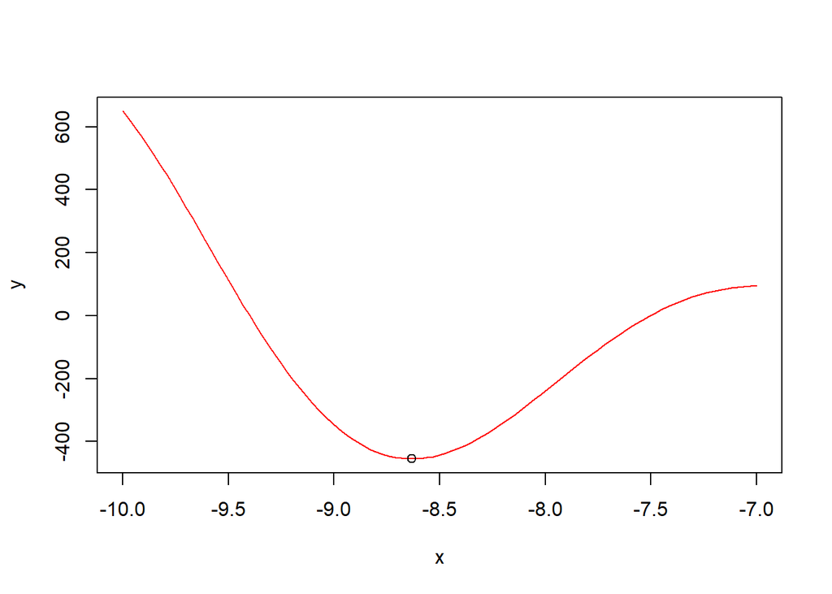

### Parameters 3

Function is called with values e=0.0001, a=-6.5, b=-5.

```r
goldensection_method(0.0001,-6.5,-5,fx)
```

```
## 1 -6.5 -5.572949 -6.145898 -5.927051 2.474379 -13.51464 0.763932 0.2692765
## 2 -6.145898 -5.572949 -5.927051 -5.791796 -13.51464 -15.96672 0.309017 1.174359
## 3 -5.927051 -5.572949 -5.791796 -5.708204 -15.96672 -14.59944 0.236068 1.443635
## 4 -5.927051 -5.708204 -5.843459 -5.791796 -15.72087 -15.96672 1.618034 -0.4812118
## 5 -5.843459 -5.708204 -5.791796 -5.759867 -15.96672 -15.69794 0.618034 0.4812118
## 6 -5.843459 -5.759867 -5.811529 -5.791796 -15.97286 -15.96672 0.618034 0.4812118
## 7 -5.843459 -5.791796 -5.823725 -5.811529 -15.91496 -15.97286 0.236068 1.443635
## 8 -5.823725 -5.791796 -5.811529 -5.803992 -15.97286 -15.98504 1.618034 -0.4812118
## 9 -5.811529 -5.791796 -5.803992 -5.799334 -15.98504 -15.98359 0.236068 1.443635
## 10 -5.811529 -5.799334 -5.806871 -5.803992 -15.98251 -15.98504 1.618034 -0.4812118
## 11 -5.806871 -5.799334 -5.803992 -5.802213 -15.98504 -15.9853 0.618034 0.4812118
## 12 -5.803992 -5.799334 -5.802213 -5.801113 -15.9853 -15.98495 0.236068 1.443635
## 13 -5.803992 -5.801113 -5.802892 -5.802213 -15.98532 -15.9853 1.618034 -0.4812118
## 14 -5.803992 -5.802213 -5.803312 -5.802892 -15.98526 -15.98532 0.236068 1.443635
## 15 -5.803312 -5.802213 -5.802892 -5.802633 -15.98532 -15.98533 1.618034 -0.4812118
## 16 -5.802892 -5.802213 -5.802633 -5.802472 -15.98533 -15.98532 0.236068 1.443635
## 17 -5.802892 -5.802472 -5.802732 -5.802633 -15.98533 -15.98533 1.618034 -0.4812118
## 18 -5.802732 -5.802472 -5.802633 -5.802571 -15.98533 -15.98533 0.618034 0.4812118
## 19 -5.802732 -5.802571 -5.802671 -5.802633 -15.98533 -15.98533 0.618034 0.4812118
## 20 -5.802732 -5.802633 -5.802694 -5.802671 -15.98533 -15.98533 0.236068 1.443635
```

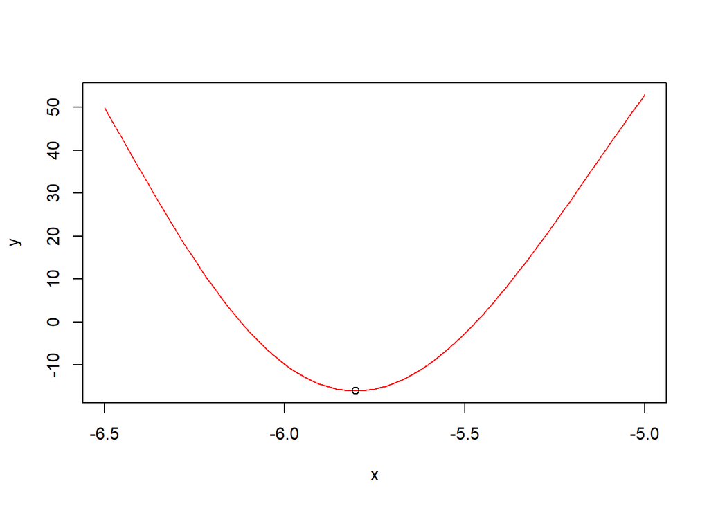

# 3-) Newton’s Method

Newton’s Method, also known as the Newton Raphson Method, is significant because it is an iterative procedure that may accurately estimate solutions to equations. It’s also a technique for approximating numerical solutions (such as x-intercepts, zeros, or roots) to equations that are too difficult to solve by hand.

### Inputs, Outputs and Function Code

Inputs : first iterate(x0), epsilon(e), function(fx), first derivative of the fx(f1x), second derivative of the fx(f2x)  
Outputs : x’, f(x’)

```r
firstderivfx <- function(x)(((-x^3)*(sin(x)^2))+((3*(x^2)*(cos(x))+6*x)*sin(x))+((x^3)*(cos(x)^2))+(3*(x^2)*cos(x))-3)
secondderivfx <- function(x)((-6*(x^2)*(sin(x)^2))+(((6*x-(4*(x^3)))*cos(x)-3*(x^2)+6)*(sin(x)))+(6*(x^2)*cos(x))+(12*x*cos(x)))
```

```r
newtons_method <- function(x0,e,fx,f1x,f2x){
  i <- 1
  temp=x0
  old <- 0
  while(abs(f1x(temp))>e){
    new = temp - (f1x(temp)/f2x(temp))
    cat(i,temp,fx(temp),f1x(temp),f2x(temp),(abs(new-temp)/(abs(temp-old)^2)),"\n")
    old<- temp
    temp = new
    i <- i+1
  }
}
```

### Parameters 1

Function is called with values a=-9, e=0.001.

```r
newtons_method(-9,0.001,fx,firstderivfx,secondderivfx)
```

```
## 1 -9 -346.8796 -592.2762 745.3846 0.009809771
## 2 -8.205409 -343.5794 460.501 421.0446 1.732266
## 3 -9.299119 -104.6009 -999.9936 12.57433 66.48254
## 4 70.22749 150489.3 -197950.1 -573153.8 5.46084e-05
## 5 69.88212 180479.1 30651.86 -684452.4 0.3754435
## 6 69.92691 181157.7 -373.2859 -688004 0.270535
## 7 69.92636 181157.8 3.412065 -687993.6 16.84736
## 8 69.92637 181157.8 -0.03120359 -687993.7 1843.972
```

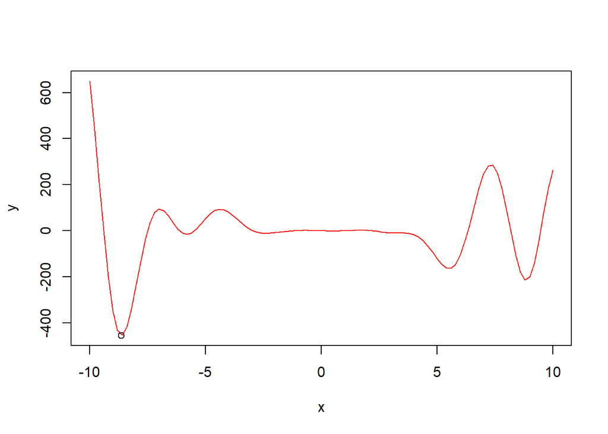

### Parameters 2

Function is called with values a=-5.5, e=0.00001

```r
newtons_method(-5.5,0.00001,fx,firstderivfx,secondderivfx)
```

```
## 1 -5.5 -2.658901 82.66718 247.9554 0.01102134
## 2 -5.833395 -15.83538 -9.771557 337.6312 0.2603766
## 3 -5.804454 -15.98481 -0.5693381 336.5037 2.019938
## 4 -5.802762 -15.98532 -0.03431351 336.3935 35.63335
## 5 -5.80266 -15.98533 -0.002069458 336.3867 591.2656
## 6 -5.802654 -15.98533 -0.0001248142 336.3862 9803.701
```

[figure not shown]

### Parameters 3

Function is called with values a=8.5, e=0.0000001.

```r
newtons_method(8.5,0.0000001,fx,firstderivfx,secondderivfx)
```

```
## 1 8.5 -147.637 -365.9394 389.2706 0.01301127
## 2 9.440064 -19.54922 573.7635 -694.5883 0.9347392
## 3 10.26611 271.0863 -223.3357 -2743.601 0.1192961
## 4 10.18471 282.6157 -61.49393 -2704.478 3.431424
## 5 10.16197 283.5194 -18.15526 -2683.439 13.08619
## 6 10.15521 283.5992 -5.445028 -2676.362 44.44608
## 7 10.15317 283.6064 -1.640255 -2674.162 148.1881
## 8 10.15256 283.607 -0.4947525 -2673.493 491.8829
## 9 10.15237 283.6071 -0.1492912 -2673.29 1630.685
## 10 10.15232 283.6071 -0.04505378 -2673.229 5404.047
## 11 10.1523 283.6071 -0.01359702 -2673.21 17906.9
## 12 10.1523 283.6071 -0.004103562 -2673.205 59334.52
## 13 10.15229 283.6071 -0.001238453 -2673.203 196603
## 14 10.15229 283.6071 -0.000373765 -2673.202 651435.6
## 15 10.15229 283.6071 -0.0001128023 -2673.202 2158502
## 16 10.15229 283.6071 -3.404372e-05 -2673.202 7152095
## 17 10.15229 283.6071 -1.027439e-05 -2673.202 23698123
## 18 10.15229 283.6071 -3.100812e-06 -2673.202 78522641
## 19 10.15229 283.6071 -9.358265e-07 -2673.202 260181950
## 20 10.15229 283.6071 -2.824317e-07 -2673.202 862087533
```

[figure not shown]

# 4-) Secant Method

The secant technique is a root-finding procedure in numerical analysis that employs a series of roots of secant lines to better approximate a root of a function f. It’s possible to think of the secant approach as a finite-difference approximation of Newton’s method.

### Inputs, Outputs and Function Code

Inputs : first iterate(x0), second iterate(x2), epsilon(e), function(fx), first derivative of the fx(f1x)  
Outputs : x’, f(x’)

```r
secant_method <- function(x0,x1,e,fx,f1x){
  i <- 1
  temp0=x0
  temp1=x1
  while(abs(f1x(temp1))>e){
    new = temp1 - ((temp1-temp0)*(f1x(temp1)/(f1x(temp1)-f1x(temp0))))
    cat(i,temp1,fx(temp1),f1x(temp1),(abs(new-temp1)/(abs(temp1-temp0)^(1.618))),"\n")
    temp0 = temp1
    temp1 = new
    i <- i+1
  }
}
```

### Parameters 1

Function is called with values x0=-9, x1=-8.5, e=0.001.

```r
secant_method(-9,-8.5,0.001,fx,firstderivfx)
```

```
## 1 -8.5 -442.7812 180.4129 0.3583433
## 2 -8.616744 -454.7402 20.68962 0.488466
## 3 -8.631866 -454.8853 -1.553573 0.9313895
## 4 -8.63081 -454.8861 0.01014877 0.4483069
```

The minimum point is (-8.63081 ,-454.8861).

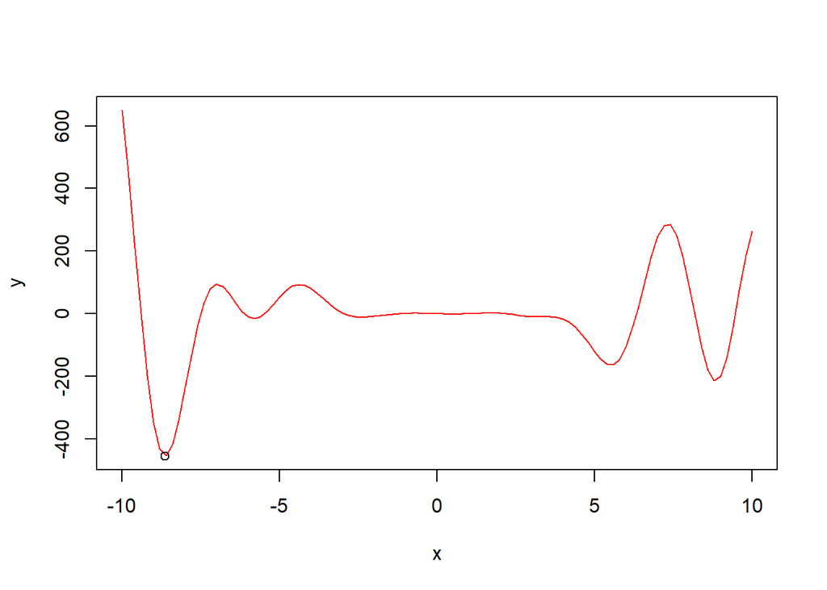

### Parameters 2

Function is called with values x0=8.5, x1=9, e=0.00001.

```r
secant_method(8.5,9,0.00001,fx,firstderivfx)
```

```
## 1 9 -200.5901 187.9757 0.5208288
## 2 8.830321 -214.9505 -19.06145 0.275548
## 3 8.845943 -215.1001 -0.07629496 0.0525234
## 4 8.846006 -215.1002 0.0001789118 0.9248568
```

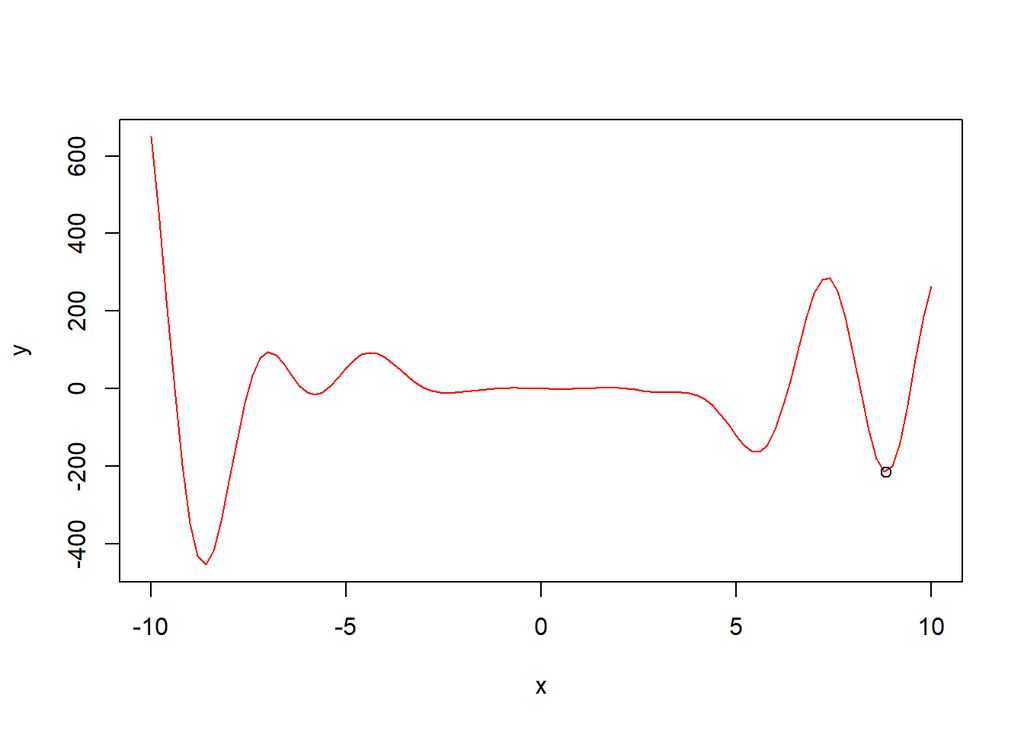

### Parameters 3

Function is called with values x0=-6.5, x1=-6, e=0.00000001

```r
secant_method(-6.5,-6,0.00000001,fx,firstderivfx)
```

```
## 1 -6 -9.773001 -62.65808 1.144739
## 2 -5.627059 -11.29521 52.03345 0.8345989
## 3 -5.796256 -15.97886 2.019558 0.1210654
## 4 -5.803088 -15.9853 -0.137304 1.38709
## 5 -5.802653 -15.98533 0.0001883272 0.1637166
## 6 -5.802653 -15.98533 1.704653e-08 0.6364775
```

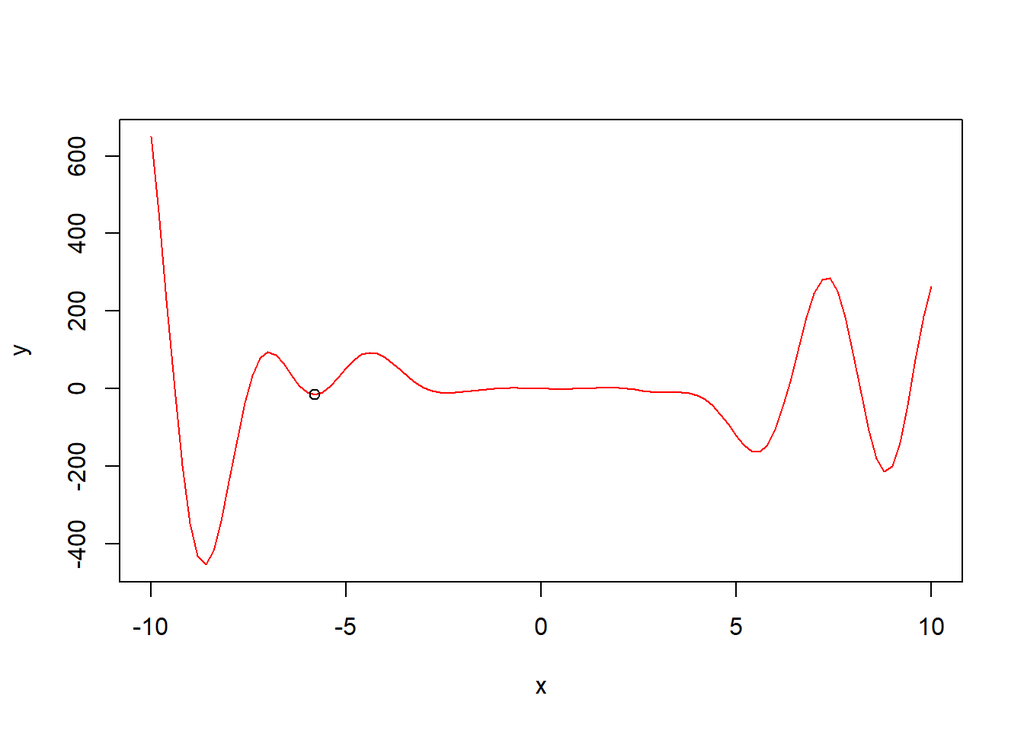